# Prosper Loan Data Analysis

## Introduction

#### The Prosper Loan data set contains 113,937 loans with 81 variables on each loan, including loan amount, borrower rate (or interest rate), current loan status, borrower income, and many others.

## Preliminary Wrangling

```python
# import all packages and set plots to be embedded inline
import numpy as np
import pandas as pd
import matplotlib.pyplot as plt
import seaborn as sb

%matplotlib inline
```

```python
# Importing Dataset
loan_data = pd.read_csv('prosperLoanData.csv')
```

```python
loan_data.shape
```

```
(113937, 81)
```

```python
# Examining Dataset
loan_data.head()
```

|  | ListingKey | ListingNumber | ListingCreationDate | CreditGrade | Term | LoanStatus | ClosedDate | BorrowerAPR | BorrowerRate | LenderYield | ... | LP_ServiceFees | LP_CollectionFees | LP_GrossPrincipalLoss | LP_NetPrincipalLoss | LP_NonPrincipalRecoverypayments | PercentFunded | Recommendations | InvestmentFromFriendsCount | InvestmentFromFriendsAmount | Investors |
| --- | --- | --- | --- | --- | --- | --- | --- | --- | --- | --- | --- | --- | --- | --- | --- | --- | --- | --- | --- | --- | --- |
| 0 | 1021339766868145413AB3B | 193129 | 2007-08-26 19:09:29.263000000 | C | 36 | Completed | 2009-08-14 00:00:00 | 0.16516 | 0.1580 | 0.1380 | ... | -133.18 | 0.0 | 0.0 | 0.0 | 0.0 | 1.0 | 0 | 0 | 0.0 | 258 |
| 1 | 10273602499503308B223C1 | 1209647 | 2014-02-27 08:28:07.900000000 | NaN | 36 | Current | NaN | 0.12016 | 0.0920 | 0.0820 | ... | 0.00 | 0.0 | 0.0 | 0.0 | 0.0 | 1.0 | 0 | 0 | 0.0 | 1 |
| 2 | 0EE9337825851032864889A | 81716 | 2007-01-05 15:00:47.090000000 | HR | 36 | Completed | 2009-12-17 00:00:00 | 0.28269 | 0.2750 | 0.2400 | ... | -24.20 | 0.0 | 0.0 | 0.0 | 0.0 | 1.0 | 0 | 0 | 0.0 | 41 |
| 3 | 0EF5356002482715299901A | 658116 | 2012-10-22 11:02:35.010000000 | NaN | 36 | Current | NaN | 0.12528 | 0.0974 | 0.0874 | ... | -108.01 | 0.0 | 0.0 | 0.0 | 0.0 | 1.0 | 0 | 0 | 0.0 | 158 |
| 4 | 0F023589499656230C5E3E2 | 909464 | 2013-09-14 18:38:39.097000000 | NaN | 36 | Current | NaN | 0.24614 | 0.2085 | 0.1985 | ... | -60.27 | 0.0 | 0.0 | 0.0 | 0.0 | 1.0 | 0 | 0 | 0.0 | 20 |

5 rows × 81 columns

```python
loan_data.describe()
```

|  | ListingNumber | Term | BorrowerAPR | BorrowerRate | LenderYield | EstimatedEffectiveYield | EstimatedLoss | EstimatedReturn | ProsperRating (numeric) | ProsperScore | ... | LP_ServiceFees | LP_CollectionFees | LP_GrossPrincipalLoss | LP_NetPrincipalLoss | LP_NonPrincipalRecoverypayments | PercentFunded | Recommendations | InvestmentFromFriendsCount | InvestmentFromFriendsAmount | Investors |
| --- | --- | --- | --- | --- | --- | --- | --- | --- | --- | --- | --- | --- | --- | --- | --- | --- | --- | --- | --- | --- | --- |
| count | 1.139370e+05 | 113937.000000 | 113912.000000 | 113937.000000 | 113937.000000 | 84853.000000 | 84853.000000 | 84853.000000 | 84853.000000 | 84853.000000 | ... | 113937.000000 | 113937.000000 | 113937.000000 | 113937.000000 | 113937.000000 | 113937.000000 | 113937.000000 | 113937.000000 | 113937.000000 | 113937.000000 |
| mean | 6.278857e+05 | 40.830248 | 0.218828 | 0.192764 | 0.182701 | 0.168661 | 0.080306 | 0.096068 | 4.072243 | 5.950067 | ... | -54.725641 | -14.242698 | 700.446342 | 681.420499 | 25.142686 | 0.998584 | 0.048027 | 0.023460 | 16.550751 | 80.475228 |
| std | 3.280762e+05 | 10.436212 | 0.080364 | 0.074818 | 0.074516 | 0.068467 | 0.046764 | 0.030403 | 1.673227 | 2.376501 | ... | 60.675425 | 109.232758 | 2388.513831 | 2357.167068 | 275.657937 | 0.017919 | 0.332353 | 0.232412 | 294.545422 | 103.239020 |
| min | 4.000000e+00 | 12.000000 | 0.006530 | 0.000000 | -0.010000 | -0.182700 | 0.004900 | -0.182700 | 1.000000 | 1.000000 | ... | -664.870000 | -9274.750000 | -94.200000 | -954.550000 | 0.000000 | 0.700000 | 0.000000 | 0.000000 | 0.000000 | 1.000000 |
| 25% | 4.009190e+05 | 36.000000 | 0.156290 | 0.134000 | 0.124200 | 0.115670 | 0.042400 | 0.074080 | 3.000000 | 4.000000 | ... | -73.180000 | 0.000000 | 0.000000 | 0.000000 | 0.000000 | 1.000000 | 0.000000 | 0.000000 | 0.000000 | 2.000000 |
| 50% | 6.005540e+05 | 36.000000 | 0.209760 | 0.184000 | 0.173000 | 0.161500 | 0.072400 | 0.091700 | 4.000000 | 6.000000 | ... | -34.440000 | 0.000000 | 0.000000 | 0.000000 | 0.000000 | 1.000000 | 0.000000 | 0.000000 | 0.000000 | 44.000000 |
| 75% | 8.926340e+05 | 36.000000 | 0.283810 | 0.250000 | 0.240000 | 0.224300 | 0.112000 | 0.116600 | 5.000000 | 8.000000 | ... | -13.920000 | 0.000000 | 0.000000 | 0.000000 | 0.000000 | 1.000000 | 0.000000 | 0.000000 | 0.000000 | 115.000000 |
| max | 1.255725e+06 | 60.000000 | 0.512290 | 0.497500 | 0.492500 | 0.319900 | 0.366000 | 0.283700 | 7.000000 | 11.000000 | ... | 32.060000 | 0.000000 | 25000.000000 | 25000.000000 | 21117.900000 | 1.012500 | 39.000000 | 33.000000 | 25000.000000 | 1189.000000 |

8 rows × 61 columns

```python
loan_data.info()
```

```
<class 'pandas.core.frame.DataFrame'>
RangeIndex: 113937 entries, 0 to 113936
Data columns (total 81 columns):
ListingKey                             113937 non-null object
ListingNumber                          113937 non-null int64
ListingCreationDate                    113937 non-null object
CreditGrade                            28953 non-null object
Term                                   113937 non-null int64
LoanStatus                             113937 non-null object
ClosedDate                             55089 non-null object
BorrowerAPR                            113912 non-null float64
BorrowerRate                           113937 non-null float64
LenderYield                            113937 non-null float64
EstimatedEffectiveYield                84853 non-null float64
EstimatedLoss                          84853 non-null float64
EstimatedReturn                        84853 non-null float64
ProsperRating (numeric)                84853 non-null float64
ProsperRating (Alpha)                  84853 non-null object
ProsperScore                           84853 non-null float64
ListingCategory (numeric)              113937 non-null int64
BorrowerState                          108422 non-null object
Occupation                             110349 non-null object
EmploymentStatus                       111682 non-null object
EmploymentStatusDuration               106312 non-null float64
IsBorrowerHomeowner                    113937 non-null bool
CurrentlyInGroup                       113937 non-null bool
GroupKey                               13341 non-null object
DateCreditPulled                       113937 non-null object
CreditScoreRangeLower                  113346 non-null float64
CreditScoreRangeUpper                  113346 non-null float64
FirstRecordedCreditLine                113240 non-null object
CurrentCreditLines                     106333 non-null float64
OpenCreditLines                        106333 non-null float64
TotalCreditLinespast7years             113240 non-null float64
OpenRevolvingAccounts                  113937 non-null int64
OpenRevolvingMonthlyPayment            113937 non-null float64
InquiriesLast6Months                   113240 non-null float64
TotalInquiries                         112778 non-null float64
CurrentDelinquencies                   113240 non-null float64
AmountDelinquent                       106315 non-null float64
```

[output cut: 31 more lines]

```
LP_CustomerPayments                    113937 non-null float64
LP_CustomerPrincipalPayments           113937 non-null float64
LP_InterestandFees                     113937 non-null float64
LP_ServiceFees                         113937 non-null float64
LP_CollectionFees                      113937 non-null float64
LP_GrossPrincipalLoss                  113937 non-null float64
LP_NetPrincipalLoss                    113937 non-null float64
LP_NonPrincipalRecoverypayments        113937 non-null float64
PercentFunded                          113937 non-null float64
Recommendations                        113937 non-null int64
InvestmentFromFriendsCount             113937 non-null int64
InvestmentFromFriendsAmount            113937 non-null float64
Investors                              113937 non-null int64
dtypes: bool(3), float64(50), int64(11), object(17)
memory usage: 68.1+ MB
```

```python
loan_data.duplicated().sum()
```

```
0
```

```python
loan_data.isna().sum()
```

```
ListingKey                                  0
ListingNumber                               0
ListingCreationDate                         0
CreditGrade                             84984
Term                                        0
LoanStatus                                  0
ClosedDate                              58848
BorrowerAPR                                25
BorrowerRate                                0
LenderYield                                 0
EstimatedEffectiveYield                 29084
EstimatedLoss                           29084
EstimatedReturn                         29084
ProsperRating (numeric)                 29084
ProsperRating (Alpha)                   29084
ProsperScore                            29084
ListingCategory (numeric)                   0
BorrowerState                            5515
Occupation                               3588
EmploymentStatus                         2255
EmploymentStatusDuration                 7625
IsBorrowerHomeowner                         0
CurrentlyInGroup                            0
GroupKey                               100596
DateCreditPulled                            0
CreditScoreRangeLower                     591
CreditScoreRangeUpper                     591
FirstRecordedCreditLine                   697
CurrentCreditLines                       7604
OpenCreditLines                          7604
                                        ...
TotalProsperLoans                       91852
TotalProsperPaymentsBilled              91852
OnTimeProsperPayments                   91852
ProsperPaymentsLessThanOneMonthLate     91852
ProsperPaymentsOneMonthPlusLate         91852
ProsperPrincipalBorrowed                91852
ProsperPrincipalOutstanding             91852
ScorexChangeAtTimeOfListing             95009
LoanCurrentDaysDelinquent                   0
LoanFirstDefaultedCycleNumber           96985
LoanMonthsSinceOrigination                  0
LoanNumber                                  0
LoanOriginalAmount                          0
LoanOriginationDate                         0
LoanOriginationQuarter                      0
MemberKey                                   0
MonthlyLoanPayment                          0
LP_CustomerPayments                         0
LP_CustomerPrincipalPayments                0
LP_InterestandFees                          0
LP_ServiceFees                              0
LP_CollectionFees                           0
LP_GrossPrincipalLoss                       0
LP_NetPrincipalLoss                         0
LP_NonPrincipalRecoverypayments             0
PercentFunded                               0
Recommendations                             0
InvestmentFromFriendsCount                  0
InvestmentFromFriendsAmount                 0
Investors                                   0
Length: 81, dtype: int64
```

```python
# selecting features of interest
selected_columns = ['Term','LoanStatus','LoanOriginalAmount','BorrowerRate','ProsperRating (Alpha)','DebtToIncomeRatio','ProsperScore','EmploymentStatus','StatedMonthlyIncome','Occupation','LoanOriginationDate','MonthlyLoanPayment','CreditScoreRangeLower']
```

```python
loan_selected_data = loan_data[selected_columns]
```

```python
loan_selected_data.info()
```

```
<class 'pandas.core.frame.DataFrame'>
RangeIndex: 113937 entries, 0 to 113936
Data columns (total 13 columns):
Term                     113937 non-null int64
LoanStatus               113937 non-null object
LoanOriginalAmount       113937 non-null int64
BorrowerRate             113937 non-null float64
ProsperRating (Alpha)    84853 non-null object
DebtToIncomeRatio        105383 non-null float64
ProsperScore             84853 non-null float64
EmploymentStatus         111682 non-null object
StatedMonthlyIncome      113937 non-null float64
Occupation               110349 non-null object
LoanOriginationDate      113937 non-null object
MonthlyLoanPayment       113937 non-null float64
CreditScoreRangeLower    113346 non-null float64
dtypes: float64(6), int64(2), object(5)
memory usage: 11.3+ MB
```

```python
loan_selected_data.shape
```

```
(113937, 13)
```

```python
loan_selected_data.isna().sum()
```

```
Term                         0
LoanStatus                   0
LoanOriginalAmount           0
BorrowerRate                 0
ProsperRating (Alpha)    29084
DebtToIncomeRatio         8554
ProsperScore             29084
EmploymentStatus          2255
StatedMonthlyIncome          0
Occupation                3588
LoanOriginationDate          0
MonthlyLoanPayment           0
CreditScoreRangeLower      591
dtype: int64
```

```python
# Remove loans with missing 'ProsperRating information
loan_selected_data = loan_selected_data.dropna(subset = ['ProsperRating (Alpha)']).reset_index()
```

```python
loan_selected_data.isna().sum()
```

```
index                       0
Term                        0
LoanStatus                  0
LoanOriginalAmount          0
BorrowerRate                0
ProsperRating (Alpha)       0
DebtToIncomeRatio        7296
ProsperScore                0
EmploymentStatus            0
StatedMonthlyIncome         0
Occupation               1333
LoanOriginationDate         0
MonthlyLoanPayment          0
CreditScoreRangeLower       0
dtype: int64
```

```python
# fill na with 0
loan_selected_data = loan_selected_data.fillna(0)
```

```python
loan_selected_data.isna().sum()
```

```
index                    0
Term                     0
LoanStatus               0
LoanOriginalAmount       0
BorrowerRate             0
ProsperRating (Alpha)    0
DebtToIncomeRatio        0
ProsperScore             0
EmploymentStatus         0
StatedMonthlyIncome      0
Occupation               0
LoanOriginationDate      0
MonthlyLoanPayment       0
CreditScoreRangeLower    0
dtype: int64
```

```python
# changing the data type
loan_selected_data['LoanOriginationDate']= pd.to_datetime(loan_selected_data['LoanOriginationDate'])
```

```python
loan_selected_data.info()
```

```
<class 'pandas.core.frame.DataFrame'>
RangeIndex: 84853 entries, 0 to 84852
Data columns (total 14 columns):
index                    84853 non-null int64
Term                     84853 non-null int64
LoanStatus               84853 non-null object
LoanOriginalAmount       84853 non-null int64
BorrowerRate             84853 non-null float64
ProsperRating (Alpha)    84853 non-null object
DebtToIncomeRatio        84853 non-null float64
ProsperScore             84853 non-null float64
EmploymentStatus         84853 non-null object
StatedMonthlyIncome      84853 non-null float64
Occupation               84853 non-null object
LoanOriginationDate      84853 non-null datetime64[ns]
MonthlyLoanPayment       84853 non-null float64
CreditScoreRangeLower    84853 non-null float64
dtypes: datetime64[ns](1), float64(6), int64(3), object(4)
memory usage: 9.1+ MB
```

```python
loan_selected_data.shape
```

```
(84853, 14)
```

```python
loan_selected_data.head()
```

|  | index | Term | LoanStatus | LoanOriginalAmount | BorrowerRate | ProsperRating (Alpha) | DebtToIncomeRatio | ProsperScore | EmploymentStatus | StatedMonthlyIncome | Occupation | LoanOriginationDate | MonthlyLoanPayment | CreditScoreRangeLower |
| --- | --- | --- | --- | --- | --- | --- | --- | --- | --- | --- | --- | --- | --- | --- |
| 0 | 1 | 36 | Current | 10000 | 0.0920 | A | 0.18 | 7.0 | Employed | 6125.000000 | Professional | 2014-03-03 | 318.93 | 680.0 |
| 1 | 3 | 36 | Current | 10000 | 0.0974 | A | 0.15 | 9.0 | Employed | 2875.000000 | Skilled Labor | 2012-11-01 | 321.45 | 800.0 |
| 2 | 4 | 36 | Current | 15000 | 0.2085 | D | 0.26 | 4.0 | Employed | 9583.333333 | Executive | 2013-09-20 | 563.97 | 680.0 |
| 3 | 5 | 60 | Current | 15000 | 0.1314 | B | 0.36 | 10.0 | Employed | 8333.333333 | Professional | 2013-12-24 | 342.37 | 740.0 |
| 4 | 6 | 36 | Current | 3000 | 0.2712 | E | 0.27 | 2.0 | Employed | 2083.333333 | Sales - Retail | 2013-04-18 | 122.67 | 680.0 |

### What is the structure of your dataset?

**The Original data set contains 113,937 loans with 81 variables on each loan, including loan amount, borrower rate (or interest rate), current loan status, borrower income, and many others.But I have selected few features for my analysis. So my data set contains 84853 Rows and 14 Columns.**

### What is/are the main feature(s) of interest in your dataset?

**I'm interested to predict what features are best for predicting the BorrowerRate for the loan and how Prosper rating, employment status, MonthlyLoanPayment and other features associates with various metrics in the dataset.**

### What features in the dataset do you think will help support your investigation into your feature(s) of interest?

**The Original Dataset contains so many variables.But I have selected few features for my analysis.**

## Univariate Exploration

```python
df = loan_selected_data.copy()
```

```python
base_color = sb.color_palette()[0]
```

### 1. Loan Status

**The current status of the loan: Cancelled, Chargedoff, Completed, Current, Defaulted, FinalPaymentInProgress, PastDue. The PastDue status will be accompanied by a delinquency bucket.**

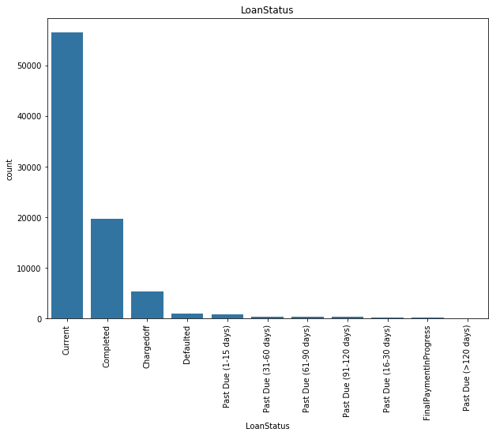

```python
plt.figure(figsize = [10, 7])
# Return the Series having unique values
count = df['LoanStatus'].value_counts()
loan_order = count.index
# see the counts for Loan Status
sb.countplot(data = df , x='LoanStatus', color=base_color,order = loan_order)
# Labeling the axes
plt.xlabel('LoanStatus')
plt.ylabel('count')
plt.title('LoanStatus')
plt.xticks(rotation=90);
```

### Observation

**Most of the loans are current loan. And the other big part is the Completed loan.The number of past due and cancelled are quite low.**

### 2. LoanOriginalAmount

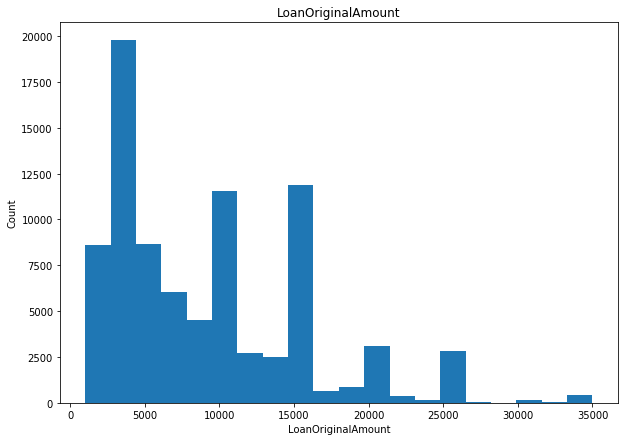

```python
# Plot the histogram  of the frequency of the 'LoanOriginalAmount'
plt.figure(figsize = [10, 7])
plt.hist(data = df, x = 'LoanOriginalAmount', bins = 20)
plt.xlabel('LoanOriginalAmount')
plt.ylabel('Count')
plt.title('LoanOriginalAmount');
```

### Observation

**The amound that borrowed many times are 4000, 15000, and 10000.**

### 3. BorrowerRate

**The Borrower's interest rate for this loan.**

```python
# Return the Series having unique values
df['BorrowerRate'].value_counts()
```

```
0.3177    3672
0.3199    1645
0.2699    1314
0.1099     932
0.3500     802
0.1585     792
0.2099     760
0.1299     756
0.2599     750
0.2199     729
0.3134     726
0.1899     698
0.1620     657
0.1840     653
0.1449     622
0.2085     608
0.2049     606
0.1249     583
0.0974     562
0.0990     560
0.1189     559
0.1465     549
0.1400     544
0.2489     534
0.1139     528
0.1535     528
0.1239     516
0.1970     515
0.1274     508
0.2346     506
          ...
0.0694       1
0.2835       1
0.3323       1
0.2810       1
0.2666       1
0.0914       1
0.1472       1
0.0760       1
0.2297       1
0.1460       1
0.1069       1
0.1518       1
0.2180       1
0.2470       1
0.1045       1
0.1403       1
0.0519       1
0.0714       1
0.3394       1
0.0690       1
0.1574       1
0.1735       1
0.1298       1
0.1669       1
0.1901       1
0.0959       1
0.1523       1
0.0843       1
0.3433       1
0.2811       1
Name: BorrowerRate, Length: 1229, dtype: int64
```

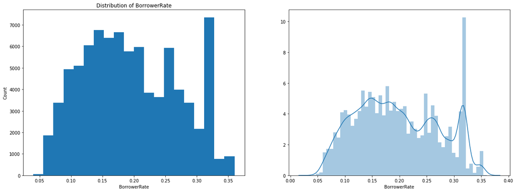

```python
# Resize the chart, and have two plots side-by-side

plt.figure(figsize = [20, 7])

# histogram on left,
# 1 row, 2 cols, subplot 1
plt.subplot(1, 2, 1)

plt.hist(data = df, x = 'BorrowerRate', bins = 20)
plt.xlabel('BorrowerRate')
plt.ylabel('Count')
plt.title('Distribution of BorrowerRate');

# similar histogram with Seaborn's distplot() on right,
plt.subplot(1, 2, 2) # 1 row, 2 cols, subplot 2
bins = np.arange(0, df['BorrowerRate'].max()+1/4, 1/4)
sb.distplot(df['BorrowerRate']);
```

### 4. EmploymentStatus

**The employment status of the borrower at the time they posted the listing.**

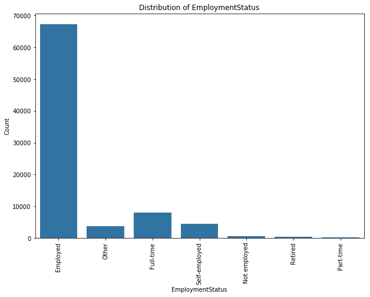

```python
# plot bar chart for EmploymentStatus
plt.figure(figsize = [10, 7])
sb.countplot(data= df, x='EmploymentStatus',color=base_color)
# Use xticks to rotate the category labels (not axes) counter-clockwise
plt.xticks(rotation = 90)
plt.xlabel('EmploymentStatus')
plt.ylabel('Count')
plt.title('Distribution of EmploymentStatus');
```

### Observation

**Most of the borrowers are employed and full-time workers.**

### 5. StatedMonthlyIncome

**The monthly income the borrower stated at the time the listing was created.**

```python
# Return the Series having unique values
df['StatedMonthlyIncome'].value_counts()
```

```
4166.666667     2773
5000.000000     2621
3333.333333     2194
5833.333333     1954
5416.666667     1913
6250.000000     1843
3750.000000     1840
6666.666667     1783
4583.333333     1739
2500.000000     1506
8333.333333     1386
2916.666667     1384
7083.333333     1218
7500.000000     1211
4333.333333     1199
10000.000000    1094
3500.000000     1040
4000.000000      949
6000.000000      861
9166.666667      834
3000.000000      831
2083.333333      813
2666.666667      769
3166.666667      704
0.000000         693
7916.666667      680
4500.000000      676
5166.666667      654
12500.000000     630
4666.666667      626
                ...
3222.333333        1
4714.000000        1
2712.916667        1
6669.833333        1
1077.416667        1
6759.250000        1
6759.500000        1
2719.416667        1
9423.500000        1
7116.583333        1
2712.666667        1
2713.000000        1
5084.916667        1
1225.000000        1
6108.166667        1
7958.000000        1
8157.416667        1
6761.000000        1
8566.666667        1
36900.000000       1
3735.833333        1
4713.250000        1
5058.083333        1
11475.000000       1
5085.166667        1
6396.333333        1
4453.000000        1
4713.750000        1
19491.666667       1
5371.333333        1
Name: StatedMonthlyIncome, Length: 9445, dtype: int64
```

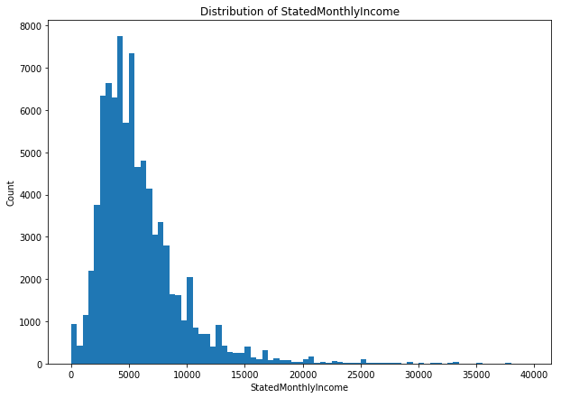

```python
# Plot a histogram of frequency of the StatedMonthlyIncome
plt.figure(figsize = [10, 7])
bin = np.arange(0, 40000, 500)
plt.hist(data = df, x = 'StatedMonthlyIncome', bins = bin)
plt.xlabel('StatedMonthlyIncome')
plt.ylabel('Count')
plt.title('Distribution of StatedMonthlyIncome');
```

### Observation

**The Stated monthly income is right skewed, with most of stated monthly income is less than 30k.**

### 6. MonthlyLoanPayment

**The scheduled monthly loan payment.**

```python
# Return the Series having unique values
df['MonthlyLoanPayment'].value_counts()
```

```
173.71     2423
172.76      536
0.00        484
86.85       469
174.20      459
130.28      370
163.28      286
326.62      280
166.54      276
136.98      274
165.15      270
161.99      265
169.78      254
163.56      252
168.17      246
168.89      227
87.10       185
166.73      181
172.56      170
108.57      163
155.80      158
172.60      155
168.32      154
384.58      146
408.20      144
127.36      143
439.30      131
204.10      127
404.54      125
322.47      122
           ...
294.81        1
591.54        1
97.34         1
205.66        1
98.14         1
108.97        1
135.95        1
374.45        1
107.81        1
197.04        1
467.03        1
110.28        1
55.06         1
1063.85       1
1076.82       1
399.39        1
445.74        1
440.58        1
710.75        1
219.10        1
572.48        1
893.82        1
104.33        1
155.19        1
322.53        1
950.39        1
269.68        1
437.28        1
299.10        1
321.74        1
Name: MonthlyLoanPayment, Length: 15184, dtype: int64
```

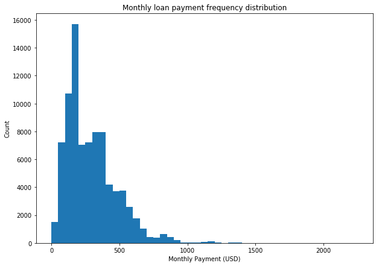

```python
plt.figure(figsize=[10, 7]);
# Create bins
bin = np.arange(0,df['MonthlyLoanPayment'].max(),50)
# Plot a histogram of frequency of the MonthlyLoanPayment
plt.hist(data = df, x = 'MonthlyLoanPayment', bins = bin)
plt.title('Monthly loan payment frequency distribution')
plt.xlabel('Monthly Payment (USD)')
plt.ylabel('Count');
```

### Observation

**The monthly loan payment is right skewed. Most of the borrower's monthly loan payment is less than 1000**

### Discuss the distribution(s) of your variable(s) of interest. Were there any unusual points? Did you need to perform any transformations?

**Most of the loans are current loan. And the other big part is the Completed loan.The number of past due and cancelled are quite low.**

**The Stated monthly income is right skewed with large range and lot of outliers . Most of stated monthly income is less than 30k.**

**The monthly loan payment is right skewed. Most of the borrower's monthly loan payment is less than 1000**

**Most of the borrowers are employed and full-time workers.**

### Of the features you investigated, were there any unusual distributions? Did you perform any operations on the data to tidy, adjust, or change the form of the data? If so, why did you do this?

**I changed the datatype of the LoanOriginationDate Object to datetime.**

**I think the main ones for borrowers credit score, debt to income ratio, loans status, loan amount, interest rate,monthly loan payment and monthly income. So the Bivariate Expolration I think to investigate the relation between all these variables.**

## Bivariate Exploration

### 1. EmploymentStatus vs BorrowerRate

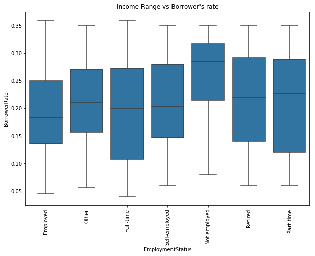

```python
# plot: box plot of the  EmploymentStatus vs BorrowerRate
plt.figure(figsize = [10, 7])
sb.boxplot(data=df, x='EmploymentStatus', y='BorrowerRate', color=base_color)
plt.title('Income Range vs Borrower\'s rate')
# Use xticks to rotate the category labels (not axes) counter-clockwise
plt.xticks(rotation=90);
```

### Observation

**The Heighest borrower rate is for borrowers with Not Employed Status.And the lowest borrower rate is for borrowers with Employed status.**

### 2. Loan Status vs BorrowerRate

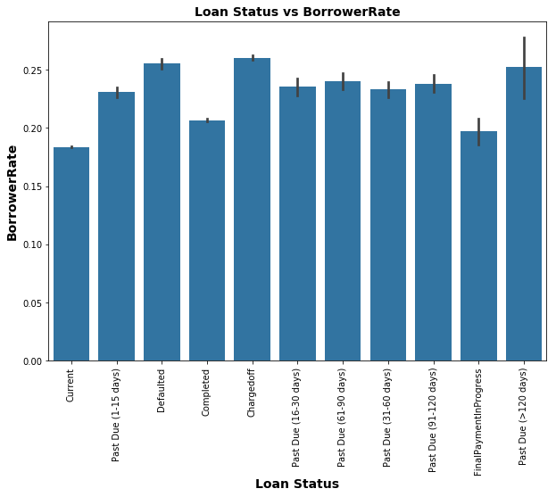

```python
plt.figure(figsize = [10, 7])
#  plot
sb.barplot(data=df, x='LoanStatus', y='BorrowerRate', color=base_color)
plt.title('Loan Status vs BorrowerRate',fontsize = 14, weight = 'bold')
plt.xlabel('Loan Status',fontsize = 14, weight = 'bold')
plt.ylabel('BorrowerRate',fontsize = 14, weight = 'bold')
# Use xticks to rotate the category labels (not axes) counter-clockwise
plt.xticks(rotation=90);
```

### 3. LoanOriginationYear vs LoanOriginalAmount

```python
df['LoanOriginationYear'] = df['LoanOriginationDate'].dt.year
df['LoanOriginationYear']
```

```
0        2014
1        2012
2        2013
3        2013
4        2013
5        2013
6        2013
7        2013
8        2012
9        2014
10       2013
11       2013
12       2012
13       2013
14       2013
```

[output cut: 47 more lines]

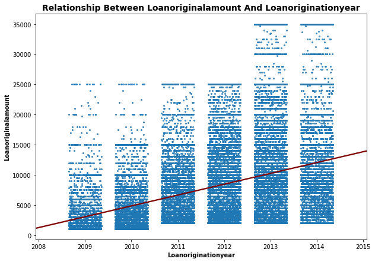

```python
def myRegplot(df,xVar,yVar,x_jitter = 0.35,y_jitter=0):
#     plot dimensions
    plt.figure(figsize = [10, 7])
    sb.regplot(data = df , x = xVar, y = yVar,x_jitter = 0.35, scatter_kws={'s':4},line_kws = {'color':'maroon'});
#     add title and labels
    plt.title(f'Relationship Between {yVar} and {xVar}'.title(), fontsize = 14, weight = 'bold')
    plt.xlabel(xVar.title(), fontsize = 10, weight = "bold")
    plt.ylabel(yVar.title(),fontsize = 10, weight = "bold")

myRegplot(df, 'LoanOriginationYear','LoanOriginalAmount')
```

### Observation

**At the beginning the Loan Origination Amount is less comparatively. And Regplot shows an increase in rates in the coming year**

### 4. LoanOriginationYear vs Borrower Rate

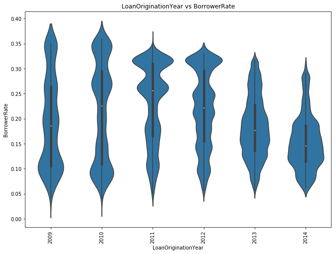

```python
# violinplot for LoanOriginationYear vs Borrower Rate
plt.figure(figsize = [11, 8])
sb.violinplot(data=df, x='LoanOriginationYear', y='BorrowerRate', color=base_color)
plt.xticks(rotation=15)
plt.xlabel('LoanOriginationYear')
plt.ylabel('BorrowerRate')
plt.title('LoanOriginationYear vs BorrowerRate');
# Use xticks to rotate the category labels (not axes) counter-clockwise
plt.xticks(rotation=90);
```

### Observation

**The Borrower Rate is increasing in 2009, 2010, and 2011 then its tend to decreasing.**

### 5. LoanOriginalAmount vs Borrower Rate

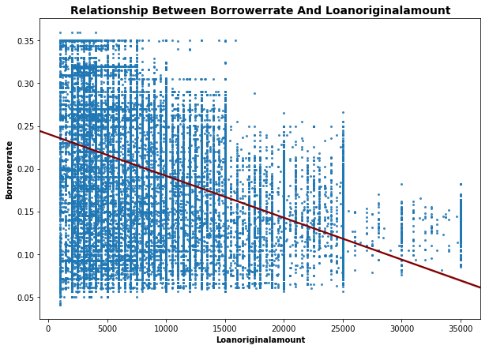

```python
#  see the relationship between borrower rate nad loan original amount
myRegplot(df, 'LoanOriginalAmount','BorrowerRate')
```

### Observation

**This plot shows that Borrower Rate limit decreases as the loan amount increases. Overall, the borrower's rate is negatively related to the loan amount.**

### 6. ProsperScore vs Borrower Rate

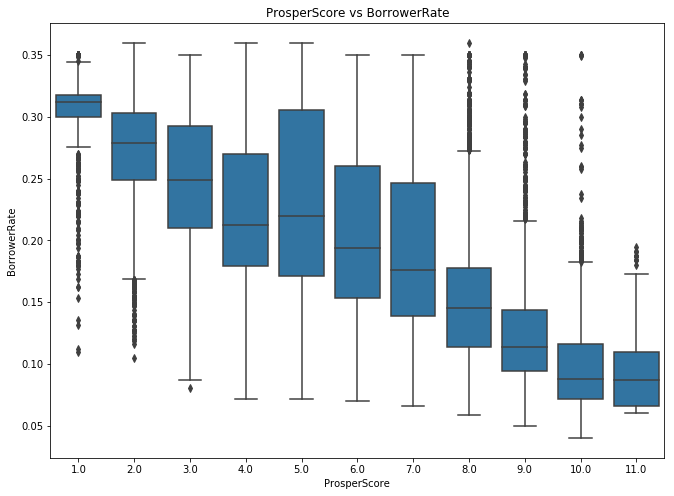

```python
# see the relation between ProsperScore vs Borrower Rate
plt.figure(figsize = [11, 8])
sb.boxplot(data=df, x='ProsperScore', y='BorrowerRate',color = base_color)
plt.xlabel('ProsperScore')
plt.ylabel('BorrowerRate')
plt.title('ProsperScore vs BorrowerRate');
```

### Observation

**The Plot shows that there is a strong relation between borrower rate and Prosper score, Higher the Prosperscore, lower the Borrower rate**

### 7. Occupation vs MonthlyLoanPayment

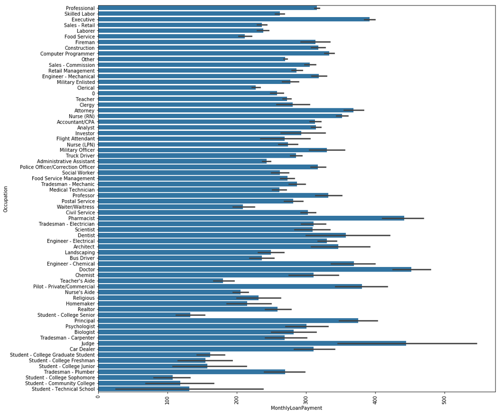

```python
# see the relation between Occupation vs MonthlyLoanPayment
plt.figure(figsize = [15, 15])
sb.barplot(data=df, y='Occupation', x='MonthlyLoanPayment', color=base_color)
# Use xticks to rotate the category labels (not axes) counter-clockwise
plt.xticks(rotation=90);
```

### Observation

**The top 3 occupations with the highest monthly loan repayment are Judge, Doctor and Pharmacist. The monthly loan payment should be positively related to the salary.**

### 8. MonthlyLoanPayment vs CreditScoreRangeLower

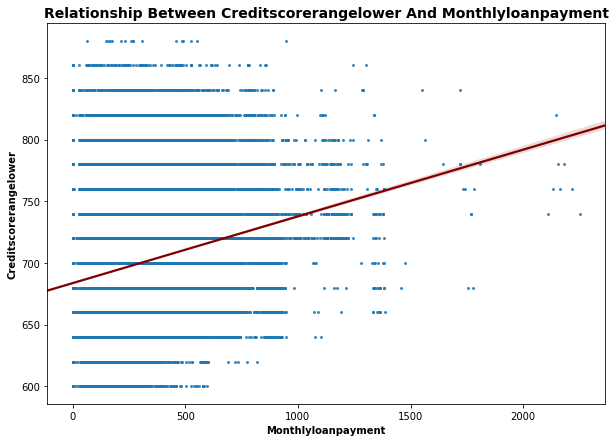

```python
# see the relationship between monthly loan payment and credit score
myRegplot(df,'MonthlyLoanPayment','CreditScoreRangeLower',x_jitter = 0, y_jitter = 7.5,)
```

### Observation

**MonthlyLoanPayment and CreditScore are actively linked. As loan repayments increase, increase the credit score also.**

### How did the feature(s) of interest vary with other features in the dataset?

**I mainly observed the relationship between the borrower rate and other features.**

### Did you observe any interesting relationships between the other features (not the main feature(s) of interest)?

**I observed that in 2009,2010, 2011 there comparitively orininated very less loan amount. and it's gradually increasing after the coming year. At the same years the Borrower rate is at the peak.So I got a conclusion that the loan amount increases, decreases the interest rate.**

## Multivariate Exploration

### Employment status and ProsperScore vs LoanStatus

```python
# combining all past due values and create a loanstatus variable
df['LoanStatus_new']=df['LoanStatus']
df.loc[df['LoanStatus_new'].str.contains("Past Due"),'LoanStatus_new' ]="Past Due"
is_order=['Completed','FinalPaymentInProgress','Current','Past Due','Defaulted','Chargedoff']
```

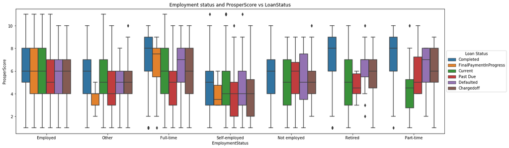

```python
# plot: box plot for the Employment status and ProsperScore vs LoanStatus
plt.figure(figsize=[20,6]);
sb.boxplot(data = df, x = 'EmploymentStatus', y = 'ProsperScore', hue = 'LoanStatus_new', hue_order = is_order)
plt.title('Employment status and ProsperScore vs LoanStatus');
plt.legend(loc='center left',bbox_to_anchor=(1,0.5),title='Loan Status')
```

### Observation

**Full time workers, Retired and Part time employers with complete loan status has highest prosper score.**

### Numerical variables Analysis

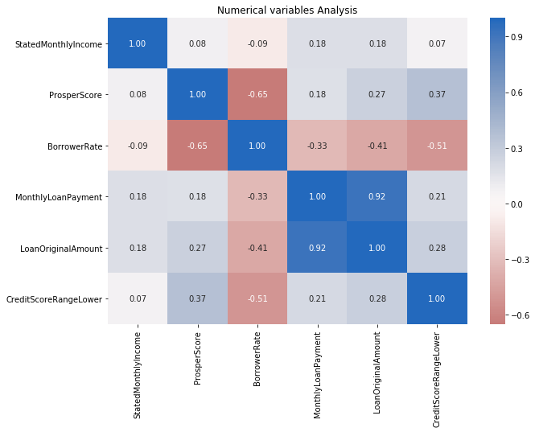

```python
# correlation plot
plt.figure(figsize=[10,7]);
#  select the Numerical variables
df_cat = ['StatedMonthlyIncome','ProsperScore','BorrowerRate','MonthlyLoanPayment','LoanOriginalAmount','CreditScoreRangeLower']

# Use cmap to reverse the color map.
sb.heatmap(df[df_cat].corr(), annot = True, fmt = '.2f', cmap = 'vlag_r', center = 0)
plt.title('Numerical variables Analysis');
```

### Observation

**The Plot shows that there is a strong relation between borrower rate Prosper score and CreditScoreRangeLower , Higher the Prosperscore, lower the Borrower rate.Higher the CreditScore, lower the Borrower rate** **Monthly loan payment and Prosper score has a positive correlation.** **Monthly loan payment and loan original amount has also a strong correlation**

### Were there features that strengthened each other in terms of looking at your feature(s) of interest?

**There is a strong relation between borrower rate Prosper score and CreditScoreRangeLower , Higher the Prosperscore, lower the Borrower rate.Higher the CreditScore, lower the Borrower rate** **Monthly loan payment and Prosper score has a positive correlation** **Monthly loan payment and loan original amount has also a strong correlation.** **The Employment staus loan staus and prosper ratings are releated.Full time workers, Retired and Part time employers with complete loan status has highest prosper score**

### Were there any interesting or surprising interactions between features?

**Borrowers who have the highest credit score and prosper score will have the lowest interest rates.** **The higher the loan amount, the lower the borrower's rate.** **Full-time part-time employers and retirees have a high Prosper score on completed loans.** **Outside the major variables of interest, I found that the loan amount is positively related to the stated monthly income, which makes sense as borrowers with higher monthly income can lend more money.**

## Conclusions

**The Prosper Loan data set contains 113,937 loans with 81 variables on each loan, including loan amount, borrower rate (or interest rate), current loan status, borrower income, and many others.But I have selected few features for my analysis. So my data set contains 84853 Rows and 14 Columns.The difficulties I had with the data were mainly due to understanding the variables and selecting the appropriate ones to analyze. I had to do some initial exploration of the data. I chose 'BorrowerRate' as my target variable as this number is very important for a potential borrower.**

**After setting the targeted variable, we can move on to the next step and start exploring the relationship between the variables, especially those related to our target variable.**